# Assignment 3

LAURA YE; laura.ye.lin@gmail.com

December 4, 2017

# Part 1

The data set in this assignment was obtained from a Local Area Unemployment Report, published by the US Government Department of Labor, Bureau of Labor Statistics (BLS).

## Goals

- Load data from sf_oak_metro.csv
- Use `tidyverse` packages to generate 4 separate ggplot line plots of the following:
1. Employment (numbers)
2. Labor Force (numbers)
3. Unemployment Rate (rate)
4. Unemployment (numbers)

## Load Data

First, let’s load the data:

```r
library(tidyverse)
ds <- read.table("sf_oak_metro.csv", header=T, sep=",")
ds <- t(ds)
```

## Tidy Data

Here, we tidy the data by including column names, coercing data types, and also extracted and coerced the month and year from the row names.

```r
tdf <- as.data.frame(ds)
colnames(tdf) <- c("Unemployment_Rate", "Unemployment", "Employment", "Labor_Force")

#Delete first row
df <- subset(tdf, rownames(tdf) != "Series.ID")

#Coerce column data into numeric types
df$Unemployment_Rate <- as.numeric(trimws(df$Unemployment_Rate, which="both"))
df$Unemployment <- as.numeric(trimws(df$Unemployment, which="both"))
df$Employment <- as.numeric(trimws(df$Employment, which="both"))
df$Labor_Force <- as.numeric(trimws(df$Labor_Force, which="both"))

# We also need a column for month and year in the rownames

library(zoo)
library(lubridate)

df <- df %>%
  mutate(MonthYear = as.character(rownames(df))) %>% #extract row names as monthyear
  mutate(MonthYear = gsub(".", " ", MonthYear, fixed=TRUE)) %>% # find and replace "." with " "
  mutate(MonthYear = as.yearmon(MonthYear)) %>% # convert to zoo::yearmon
  mutate(Month = as.factor(month(MonthYear))) %>%
  mutate(MonthLabel = factor(month.abb[Month], levels=month.abb))

# fix column names using snake case
source("fix_column_names.R")
df <- df %>%
  fix_column_names
```

Our tidied data frame looks like this:

```r
df %>% glimpse
```

```
Observations: 324
Variables: 7
$ unemployment_rate <dbl> 3.5, 3.3, 3.2, 3.4, 3.3, 3.5, 4.1, 3.9, 3.9,...
$ unemployment      <dbl> 70296, 66517, 63840, 67539, 67268, 71436, 83...
$ employment        <dbl> 1952945, 1948964, 1951817, 1942696, 1945080,...
$ labor_force       <dbl> 2023241, 2015481, 2015657, 2010235, 2012348,...
$ month_year        <S3: yearmon> Jan 1990, Feb 1990, Mar 1990, Apr 19...
$ month             <fctr> 1, 2, 3, 4, 5, 6, 7, 8, 9, 10, 11, 12, 1, 2...
$ month_label       <fctr> Jan, Feb, Mar, Apr, May, Jun, Jul, Aug, Sep...
```

## Plots

Now that we have a tidied data frame, let’s plot each variable in a ggplot line plot:

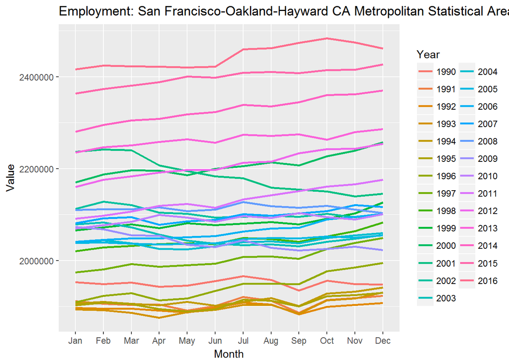

```r
library(ggplot2)
library(lubridate)

ggplot(df, aes(x=month_label,
               y=employment,
               group=factor(year(month_year)),
               colour=factor(year(month_year)))) +
  geom_line(size=1) +
  ylab("Value") +
  xlab("Month") +
  ggtitle("Employment: San Francisco-Oakland-Hayward CA Metropolitan Statistical Area") +
  labs(color='Year')
```

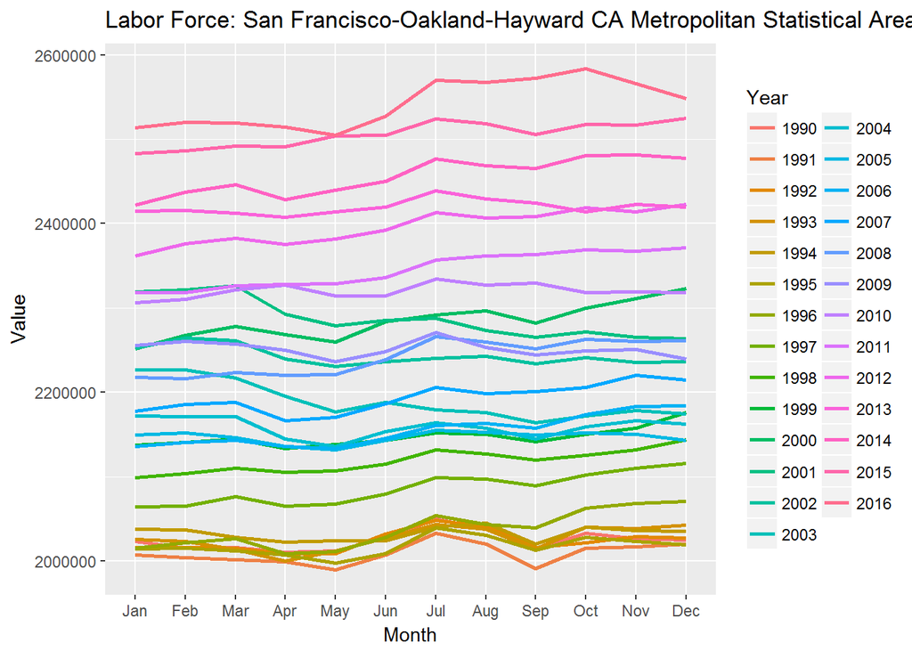

```r
ggplot(df, aes(x=month_label,
               y=labor_force,
               group=factor(year(month_year)),
               colour=factor(year(month_year)))) +
  geom_line(size=1) +
  ylab("Value") +
  xlab("Month") +
  labs(color='Year') +
  ggtitle("Labor Force: San Francisco-Oakland-Hayward CA Metropolitan Statistical Area")
```

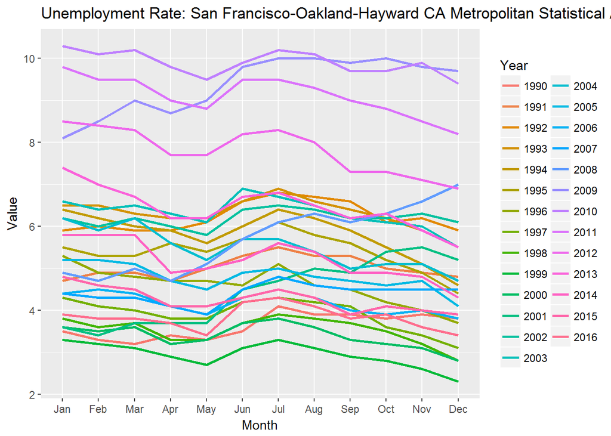

```r
ggplot(df, aes(x=month_label,
               y=unemployment_rate,
               group=factor(year(month_year)),
               colour=factor(year(month_year)))) +
  geom_line(size=1) +
  ylab("Value") +
  xlab("Month") +
  labs(color='Year')+
  ggtitle("Unemployment Rate: San Francisco-Oakland-Hayward CA Metropolitan Statistical Area")
```

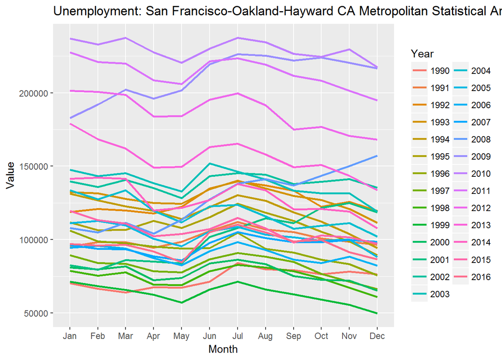

```r
ggplot(df, aes(x=month_label,
               y=unemployment,
               group=factor(year(month_year)),
               colour=factor(year(month_year)))) +
  geom_line(size=1) +
  ylab("Value") +
  xlab("Month") +
  labs(color='Year')+
  ggtitle("Unemployment: San Francisco-Oakland-Hayward CA Metropolitan Statistical Area")
```

# Part 2

## Goals

1. Leaflet chloropleth map showing all California counties only
2. Load and tidy data for unemployment rates in Dec 2016 only
3. Leaflet chloropleth map showing unemployment rates (only, with legend) for all California counties for Dec 2016 only
4. Shiny app that lets users choose the month to display the chloropleth map and also which statistic to display

## Leaflet chloropleth map showing all California counties only

gz_2010_us_050_00_20m.json stores store shape files for all US counties. Let’s load these shape files using `rgdal::readOGR`.

```r
library(geojsonio)
library(rgdal)
library(jsonlite)
library(spdplyr)
library(geojsonlint)

counties <- readOGR(dsn = "C:\\Users\\lye\\Documents\\GitHub\\r-assignments\\Data Principles and Practice\\gz_2010_us_050_00_20m.json",
                  layer = "gz_2010_us_050_00_20m", verbose = FALSE)

#fix column names
counties@data <- counties@data %>%
  fix_column_names

counties@data %>% glimpse
```

```
Observations: 3,221
Variables: 6
$ geo_id     <fctr> 0500000US01001, 0500000US01009, 0500000US01017, 05...
$ state      <fctr> 01, 01, 01, 01, 01, 01, 01, 01, 01, 01, 01, 01, 01...
$ county     <fctr> 001, 009, 017, 021, 033, 045, 051, 065, 079, 083, ...
$ name       <fctr> Autauga, Blount, Chambers, Chilton, Colbert, Dale,...
$ lsad       <fctr> County, County, County, County, County, County, Co...
$ censusarea <dbl> 594.436, 644.776, 596.531, 692.854, 592.619, 561.15...
```

Let’s filter these counties to ones that are only in California. According to FIPS State Codes, California’s state code is “06”.

```r
ca_counties <- counties %>%
  filter(state == "06")
```

Now we have California-specific shape files stored in `ca_counties`:

```r
ca_counties@data %>% glimpse
```

```
Observations: 58
Variables: 6
$ geo_id     <fctr> 0500000US06005, 0500000US06021, 0500000US06033, 05...
$ state      <fctr> 06, 06, 06, 06, 06, 06, 06, 06, 06, 06, 06, 06, 06...
$ county     <fctr> 005, 021, 033, 043, 055, 089, 099, 115, 003, 007, ...
$ name       <fctr> Amador, Glenn, Lake, Mariposa, Napa, Shasta, Stani...
$ lsad       <fctr> County, County, County, County, County, County, Co...
$ censusarea <dbl> 594.583, 1313.947, 1256.464, 1448.816, 748.362, 377...
```

Now, we are ready to start building our map, which we name `m` for convenience:

```r
library(leaflet)
m <- leaflet(ca_counties, width = "65%") %>%
  setView(-120, 37.8, 5) %>%
  addTiles()

m %>% addPolygons()
```

[interactive chart not shown]

In the map, we only see California counties, which is what we want.

## Load and tidy data for unemployment rates in Dec 2016 only

```r
library(dplyr)
library(tidyverse)
emp_data <- read_tsv("california_counties_monthly_employment_2016.tsv")

#fix column names
emp_data <- emp_data %>%
  fix_column_names %>%
  glimpse
```

```
Observations: 696
Variables: 11
$ area_code       <chr> "CN0600100000000", "CN0600300000000", "CN06005...
$ fips_state      <chr> "06", "06", "06", "06", "06", "06", "06", "06"...
$ fips_county     <chr> "001", "003", "005", "007", "009", "011", "013...
$ area_title      <chr> "Alameda County, CA", "Alpine County, CA", "Am...
$ period          <date> 2016-01-01, 2016-01-01, 2016-01-01, 2016-01-0...
$ labor_force     <dbl> 825565, 672, 14174, 101597, 20268, 10897, 5499...
$ employed        <dbl> 789959, 636, 13237, 94191, 18985, 8462, 524952...
$ unemployed      <dbl> 35606, 36, 937, 7406, 1283, 2435, 24957, 864, ...
$ unemployed_rate <dbl> 4.3, 5.4, 6.6, 7.3, 6.3, 22.3, 4.5, 8.7, 5.4, ...
$ fips            <chr> "06001", "06003", "06005", "06007", "06009", "...
$ fips_ssamatab1  <chr> "06001", "06003", "06005", "06007", "06009", "...
```

We are only interested in unemployment rate, so let’s narrow down to the columns we need: fips_county, unemployed_rate and period.

```r
unemployment_rate <- emp_data %>%
  select(fips_county, unemployed_rate, period) %>%
  mutate(fips_county = as.factor(fips_county)) %>%
  glimpse
```

```
Observations: 696
Variables: 3
$ fips_county     <fctr> 001, 003, 005, 007, 009, 011, 013, 015, 017, ...
$ unemployed_rate <dbl> 4.3, 5.4, 6.6, 7.3, 6.3, 22.3, 4.5, 8.7, 5.4, ...
$ period          <date> 2016-01-01, 2016-01-01, 2016-01-01, 2016-01-0...
```

Right now, the data is in the long format since the fips_county column do not contain unique values. We need to convert the data to the wide format in order to join the data with `ca_counties@data`.

```r
library(tidyr)
wide_data <- unemployment_rate %>%
  spread(key = fips_county, value = unemployed_rate)

wide_data %>% head
```

```
# A tibble: 6 x 59
      period `001` `003` `005` `007` `009` `011` `013` `015` `017` `019`
      <date> <dbl> <dbl> <dbl> <dbl> <dbl> <dbl> <dbl> <dbl> <dbl> <dbl>
1 2016-01-01   4.3   5.4   6.6   7.3   6.3  22.3   4.5   8.7   5.4  10.5
2 2016-02-01   4.3   5.2   6.4   7.1   6.1  21.4   4.5   8.6   5.3  10.4
3 2016-03-01   4.3   5.5   6.4   7.2   6.2  20.4   4.5   8.5   5.3  10.6
4 2016-04-01   4.1   6.0   5.9   6.4   5.7  16.1   4.3   7.5   5.0   9.6
5 2016-05-01   3.8   7.6   5.3   5.8   5.2  12.5   4.0   6.6   4.7   8.4
6 2016-06-01   4.7   7.6   6.0   7.1   6.0  13.6   4.9   7.3   5.3   9.3
# ... with 48 more variables: `021` <dbl>, `023` <dbl>, `025` <dbl>,
#   `027` <dbl>, `029` <dbl>, `031` <dbl>, `033` <dbl>, `035` <dbl>,
#   `037` <dbl>, `039` <dbl>, `041` <dbl>, `043` <dbl>, `045` <dbl>,
#   `047` <dbl>, `049` <dbl>, `051` <dbl>, `053` <dbl>, `055` <dbl>,
#   `057` <dbl>, `059` <dbl>, `061` <dbl>, `063` <dbl>, `065` <dbl>,
#   `067` <dbl>, `069` <dbl>, `071` <dbl>, `073` <dbl>, `075` <dbl>,
#   `077` <dbl>, `079` <dbl>, `081` <dbl>, `083` <dbl>, `085` <dbl>,
#   `087` <dbl>, `089` <dbl>, `091` <dbl>, `093` <dbl>, `095` <dbl>,
#   `097` <dbl>, `099` <dbl>, `101` <dbl>, `103` <dbl>, `105` <dbl>,
#   `107` <dbl>, `109` <dbl>, `111` <dbl>, `113` <dbl>, `115` <dbl>
```

For now we are only interested in data from December 2016 and we want to format it so that we have one column with COUNTY (matching `ca_counties@data`) and another with unemployment_rate. We also need to transpose the data so that there is a county column.

```r
library(lubridate)
dec_data <- wide_data %>%
  filter(year(period) == 2016 & month(period) == 12) %>%
  t() %>% as.data.frame()

dec_data <- dec_data %>%
  mutate(county = as.factor(rownames(dec_data))) %>%
  mutate(unemployment_rate = as.numeric(as.character(V1)))

dec_data = dec_data[-1,]

dec_data <- dec_data %>%
  select(county, unemployment_rate)

dec_data %>% head
```

```
  county unemployment_rate
2    001               3.8
3    003               4.8
4    005               5.7
5    007               6.3
6    009               5.4
7    011              19.5
```

Now we want to join `dec_data` with `ca_counties@data` so that the chloropleth map can link the unemployment data with each county.

```r
ca_counties@data <- ca_counties@data %>%
  inner_join(dec_data, by="county") %>%
  glimpse
```

```
Observations: 58
Variables: 7
$ geo_id            <fctr> 0500000US06005, 0500000US06021, 0500000US06...
$ state             <fctr> 06, 06, 06, 06, 06, 06, 06, 06, 06, 06, 06,...
$ county            <chr> "005", "021", "033", "043", "055", "089", "0...
$ name              <fctr> Amador, Glenn, Lake, Mariposa, Napa, Shasta...
$ lsad              <fctr> County, County, County, County, County, Cou...
$ censusarea        <dbl> 594.583, 1313.947, 1256.464, 1448.816, 748.3...
$ unemployment_rate <dbl> 5.7, 8.6, 6.8, 7.2, 4.4, 6.7, 8.3, 8.7, 4.8,...
```

We are now ready to add this data to our chloropleth map.

## Leaflet chloropleth map showing unemployment rates for all California counties for Dec 2016 only

To determine the scale for the color palette of the chloropleth map, let’s take a quick look at the boxplot for the unemployment rate:

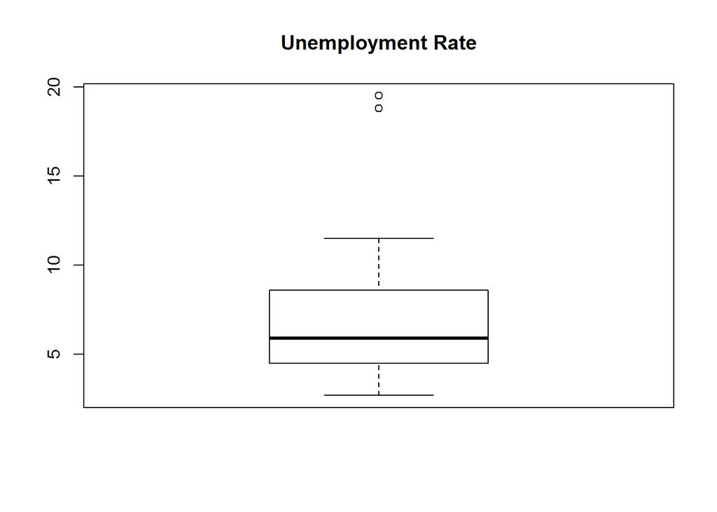

```r
boxplot(ca_counties@data$unemployment_rate)
title("Unemployment Rate")
```

We see that the data ranges from 0 to 20, with the mean around 7.

We can create bins in increments of 5, so that we can see the differences in unemployment rate across the counties in California.

```r
#Determine bins and color palette
bins <- seq(from=0,to=20, by=5)
pal <- colorBin("YlOrRd", domain = ca_counties@data$unemployment_rate, bins = bins)

#Apply color palette to polygons of county shapes
m <- m %>%
  addPolygons(
    fillColor = ~pal(ca_counties@data$unemployment_rate),
    weight = 2,
    opacity = 1,
    color = "white",
    dashArray = "3",
    fillOpacity = 0.7,
    highlight = highlightOptions(
      weight = 5,
      color = "#666",
      dashArray = "",
      fillOpacity = 0.7,
      bringToFront = TRUE)) %>%

  #Add a legend
  addLegend(pal = pal,
            values = ~ca_counties@data$unemployment_rate,
            opacity = 0.7,
            title = "Unemployment Rate (Dec 2016)",
            position = "bottomleft")

m
```

[interactive chart not shown]

## Interactive Chloropleth Map

The last goal is to create an interactive chloropleth map that lets the user select the month to display and also which statistic to display.

You can access the interactive map, hosted by Shiny, here:

https://yelaura.shinyapps.io/california_counties_statistics/